# Uygulama - Zaman Serileriyle Regresyon Analizi

Finansal Ekonometri (MPİ-TYL)

Prof. Dr. Hüseyin Taştan

Yıldız Teknik Üniversitesi

# 1 Üstel trend

```r
# load packages
library(wooldridge)
library(dynlm)
library(lmtest)
library(car)
library(forecast)
library(tidyverse)
```

```r
load("Data/gsyih_sa_endeks.RData")
tail(gsyih_sa_endeks)
```

```
## # A tibble: 6 × 5
##    year quarter gsyih_sa insaat gmenkul
##   <int> <chr>      <dbl>  <dbl>   <dbl>
## 1  2019 2           176.   204.    135.
## 2  2019 3           177.   203.    136.
## 3  2019 4           180.   201.    140.
## 4  2020 1           180.   206.    140.
## 5  2020 2           161.   202.    138.
## 6  2020 3           186.   213.    140.
```

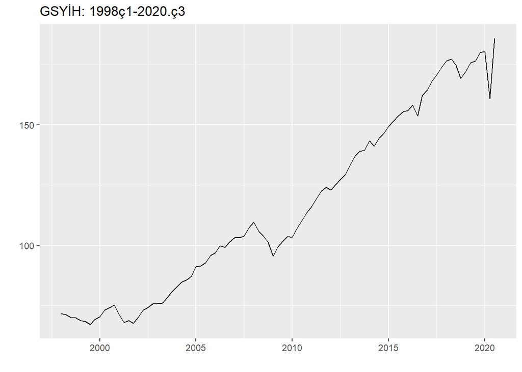

```r
# ts objeleri oluştur
# GSYİH
gsyih_sa_ts <- ts(gsyih_sa_endeks$gsyih_sa, start = c(1998,1), frequency = 4)
# zaman serisi grafiği
autoplot(gsyih_sa_ts)+
  xlab("") + ylab("") +
  ggtitle("GSYİH: 1998ç1-2020.ç3") +
  theme(legend.title = element_blank()) +
  theme(legend.position = "right")
```

```r
# log trend
# forecast::tslm() function
res1 <- tslm(log(gsyih_sa_ts) ~ trend)
summary(res1)
```

```
##
## Call:
## tslm(formula = log(gsyih_sa_ts) ~ trend)
##
## Residuals:
##      Min       1Q   Median       3Q      Max
## -0.14871 -0.02348  0.01086  0.03698  0.12785
##
## Coefficients:
##              Estimate Std. Error t value Pr(>|t|)
## (Intercept) 4.1315110  0.0109199   378.3   <2e-16 ***
## trend       0.0122027  0.0002061    59.2   <2e-16 ***
## ---
## Signif. codes:  0 '***' 0.001 '**' 0.01 '*' 0.05 '.' 0.1 ' ' 1
##
## Residual standard error: 0.05166 on 89 degrees of freedom
## Multiple R-squared:  0.9752, Adjusted R-squared:  0.975
## F-statistic:  3504 on 1 and 89 DF,  p-value: < 2.2e-16
```

$$\widehat{\log(GSYIH)} =
4.13+0.012~trend$$

GSYİH serisi her çeyrekte ortalama %1.2 büyümektedir (yıllık olarak yaklaşık %4.8).

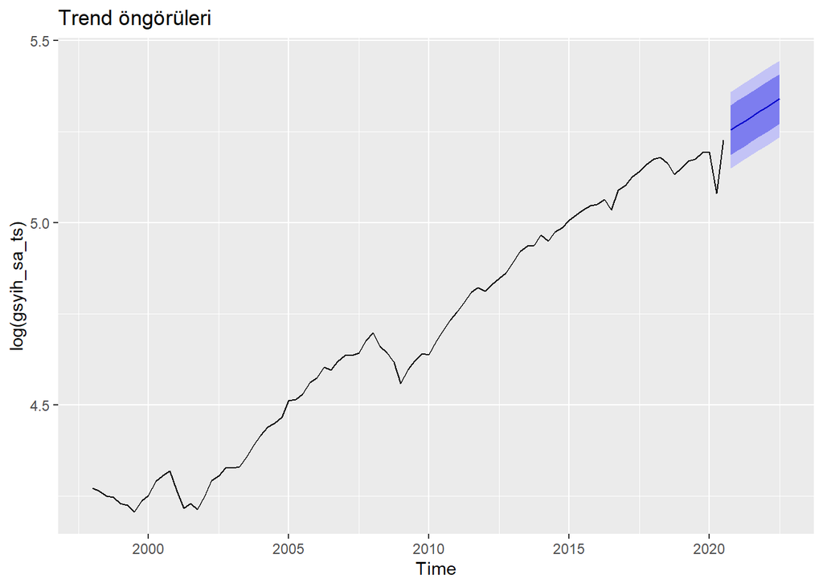

```r
autoplot(forecast(res1, h=8)) +
  ggtitle("Trend öngörüleri")
```

# 2 Birim kök testleri (durağanlık)

Değişkenlerin birinci farkını almalı mıyız? Durağan olmayan bir zaman serisini (random walk ya da random walk with drift gibi) durağanlaştırmanın tek yolu birinci farkını almaktır.

Literatürde çok sayıda birim kök testi geliştirilmiştir. Yaygın olarak kullanılan ADF testi (Augmented Dickey-Fuller) sıradan en küçük kareler regresyonlarına dayanır. En basit haliyle $y_t$ serisinin ADF test istatistiği aşağıdaki regresyonda
$$y_t = \phi
y_{t-1}+\varepsilon_t$$

gecikme katsayısının $\phi=1$ olup olmadığına ilişkin t oranıdır. Ancak boş hipotez altında bu t oranı t dağılımını takip etmez. Standart dağılımlar dışında bir dağılıma sahiptir ve kritik değerler ancak simülasyonla bulunabilir. Seride düzenli artış (trend) varsa drift (sabit) terimi eklenebilir. Ayrıca hata teriminin white noise olması (otokorelasyonsuz) gerekir. Otokorelasyonu yok etmek için bağımlı değişkenin farkının uygun gecikmeleri eklenebilir.

ADF testinin boş hipotezi:
$$H_0:~~seri~birim~kök ~içerir (durağan~~
değildir)$$

P değeri ile karar verilebilir. Yeterince büyük bir p değeri (örneğin 0.05’den büyükse) için boş hipotez kabul edilir, yani seri durağan değildir. Bu durumda serinin birinci farkını almak gerekir. Birinci farkı aldıktan sonra tekrar ADF testi hesaplanır. Eğer birinci farkın ADF p değeri yeterince küçükse birinci fark durağandır. Böylece birinci fark almanın seriyi durağanlaştırmak için yeterli olduğu sonucuna ulaşılır.

Başka bir durağanlık testi KPSS testidir. Bu testin boş hipotezi serinin durağan olduğunu söyler:
$$H_0:~~seri~durağandır$$

KPSS test istatistiğinin p değeri ile karar verilebilir. Yeterince büyük bir p değeri (örneğin 0.05’den büyükse) boş hipotez kabul edilir, yani seri durağandır.

```r
library(urca)
library(tsibble)
```

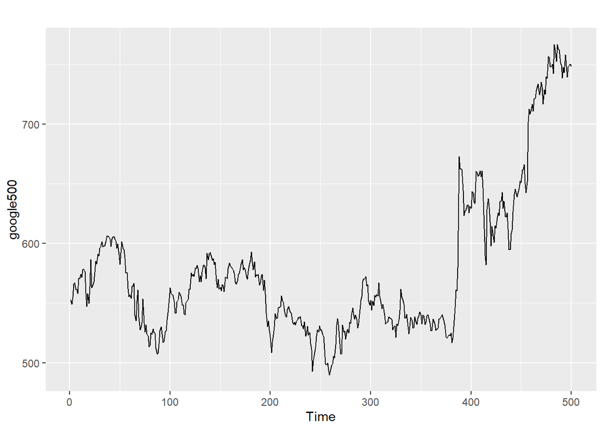

```r
library(tsibbledata)
google <- gafa_stock %>% filter(Symbol == "GOOG")
google_ts <- ts(google$Close, frequency = 1)
google500 <- window(google_ts, end = 500)
autoplot(google500)
```

```r
# ADF testi
adf1 <- ur.df(log(google500) ,
              type = c("drift"), # drift (sabit) dahil
              lags=6,            # max gecikme sayısı
              selectlags="AIC")  # optimal gecikme AIC ile seçilsin
summary(adf1)
```

```
##
## ###############################################
## # Augmented Dickey-Fuller Test Unit Root Test #
## ###############################################
##
## Test regression drift
##
##
## Call:
## lm(formula = z.diff ~ z.lag.1 + 1 + z.diff.lag)
##
## Residuals:
##       Min        1Q    Median        3Q       Max
## -0.052639 -0.008706 -0.000418  0.008179  0.145782
##
## Coefficients:
##              Estimate Std. Error t value Pr(>|t|)
## (Intercept)  0.045875   0.045456   1.009   0.3134
## z.lag.1     -0.007134   0.007153  -0.997   0.3190
## z.diff.lag   0.075733   0.045363   1.669   0.0957 .
## ---
## Signif. codes:  0 '***' 0.001 '**' 0.01 '*' 0.05 '.' 0.1 ' ' 1
##
## Residual standard error: 0.01597 on 490 degrees of freedom
## Multiple R-squared:  0.006941,   Adjusted R-squared:  0.002887
## F-statistic: 1.712 on 2 and 490 DF,  p-value: 0.1815
##
##
## Value of test-statistic is: -0.9974 0.7806
##
## Critical values for test statistics:
##       1pct  5pct 10pct
## tau2 -3.44 -2.87 -2.57
## phi1  6.47  4.61  3.79
```

ADF test istatistiği $-0.997$’dir. P değeri:

```r
punitroot(-0.997, trend = "c", statistic = "t")
```

```
## [1] 0.7565766
```

P değeri oldukça büyüktür, boş hipotez reddedilemez. Google hisse serisi durağan değildir.

Birinci farkı alalım ve testi tekrarlayalım:

```r
# Birinci farkın ADF testi
adf2 <- ur.df(diff(log(google500)) ,  # logaritmik birinci fark
              type = c("drift"), # drift (sabit) dahil
              lags=6,            # max gecikme sayısı
              selectlags="AIC")  # optimal gecikme AIC ile seçilsin
summary(adf2)
```

```
##
## ###############################################
## # Augmented Dickey-Fuller Test Unit Root Test #
## ###############################################
##
## Test regression drift
##
##
## Call:
## lm(formula = z.diff ~ z.lag.1 + 1 + z.diff.lag)
##
## Residuals:
##       Min        1Q    Median        3Q       Max
## -0.053095 -0.008600 -0.000507  0.007918  0.145614
##
## Coefficients:
##               Estimate Std. Error t value Pr(>|t|)
## (Intercept)  0.0005904  0.0007210   0.819    0.413
## z.lag.1     -0.9886206  0.0615355 -16.066   <2e-16 ***
## z.diff.lag   0.0631971  0.0451242   1.401    0.162
## ---
## Signif. codes:  0 '***' 0.001 '**' 0.01 '*' 0.05 '.' 0.1 ' ' 1
##
## Residual standard error: 0.01597 on 489 degrees of freedom
## Multiple R-squared:  0.4671, Adjusted R-squared:  0.465
## F-statistic: 214.3 on 2 and 489 DF,  p-value: < 2.2e-16
##
##
## Value of test-statistic is: -16.0659 129.056
##
## Critical values for test statistics:
##       1pct  5pct 10pct
## tau2 -3.44 -2.87 -2.57
## phi1  6.47  4.61  3.79
```

ADF test istatistiği $-16.066$, ve p değeri:

```r
punitroot(-16.066, trend = "c", statistic = "t")
```

```
## [1] 3.053593e-38
```

P değeri oldukça küçüktür, $H_0$ reddedilir. Yani birinci fark durağandır. Böylece ADF testine göre bu değişkenin birinci farkının durağanlaştırmak için yeterli olduğunu göstermiş olduk.

Şimdi KPSS testini hesaplayalım. x

```r
# KPSS testi, urca paketi
kpss1 <- ur.kpss(log(google500))
summary(kpss1)
```

```
##
## #######################
## # KPSS Unit Root Test #
## #######################
##
## Test is of type: mu with 5 lags.
##
## Value of test-statistic is: 2.9062
##
## Critical value for a significance level of:
##                 10pct  5pct 2.5pct  1pct
## critical values 0.347 0.463  0.574 0.739
```

KPSS test istatistiği 2.9062 kritik değerlerden büyüktür. Sonuç olarak boş hipotez reddedilir. Boş hipotez serinin durağan olduğunu söylüyordu. Öyleyse seri durağan değildir. KPSS testi `feasts::unitroot_kpss()` fonksiyonu ile de hesaplanabilir:

```r
feasts::unitroot_kpss(log(google500))
```

```
##   kpss_stat kpss_pvalue
##    2.906176    0.010000
```

P değeri 0.01 olduğuna göre $H_0$ reddedilir, seri durağan değildir.

Birinci fark ile tekrarlayalım:

```r
feasts::unitroot_kpss(diff(log(google500)))
```

```
##   kpss_stat kpss_pvalue
##   0.1790407   0.1000000
```

P değeri 0.05’den büyüktür. Boş hipotez kabul edilir, birinci fark durağandır.

Bir değişkenin durağanlaşması için kaç farkının alınması gerektiğini otomatik olarak `feasts::unitroot_ndiffs()` fonksiyonu ile de hesaplayabiliriz. Bu fonksiyonu KPSS testini kullanmaktadır. Google serisine uygularsak:

```r
feasts::unitroot_ndiffs(log(google500))
```

```
## ndiffs
##      1
```

Log google değişkeninin birinci farkının alınması seriyi durağanlaştırmaktadır. Birinci fark için:

```r
feasts::unitroot_ndiffs(diff(log(google500)))
```

```
## ndiffs
##      0
```

Tekrar fark almaya gerek yoktur.

# 3 Eşbütünleşme

## 3.1 Örnek: 3-aylık ve 6-aylık hazine bonosu faiz oranları eşbütünleşik mi?

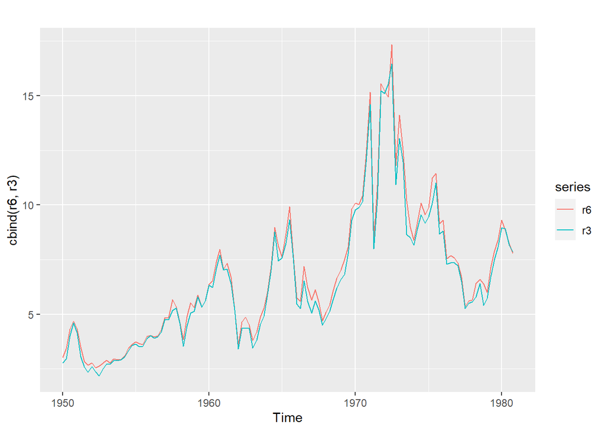

```r
library(wooldridge)
r6 <- ts(intqrt$r6, start = 1950, frequency = 4)
r3 <- ts(intqrt$r3, start = 1950, frequency = 4)
spr <- r6-r3
autoplot(cbind(r6, r3))
```

```r
intreg1 <- dynlm(r6 ~ r3)
summary(intreg1)
```

```
##
## Time series regression with "ts" data:
## Start = 1950(1), End = 1980(4)
##
## Call:
## dynlm(formula = r6 ~ r3)
##
## Residuals:
##     Min      1Q  Median      3Q     Max
## -1.1379 -0.1583 -0.0251  0.1155  1.1803
##
## Coefficients:
##             Estimate Std. Error t value Pr(>|t|)
## (Intercept) 0.135374   0.054867   2.467    0.015 *
## r3          1.025899   0.007709 133.081   <2e-16 ***
## ---
## Signif. codes:  0 '***' 0.001 '**' 0.01 '*' 0.05 '.' 0.1 ' ' 1
##
## Residual standard error: 0.2584 on 122 degrees of freedom
## Multiple R-squared:  0.9932, Adjusted R-squared:  0.9931
## F-statistic: 1.771e+04 on 1 and 122 DF,  p-value: < 2.2e-16
```

Tahmin sonuçları:
$$\widehat{r6}_t = 0.135
+ 1.03 r3_t$$

$r3_t$’nin katsayı tahmini bire çok yakındır; beklenndiği gibi bu iki değişken arasında birebir ilişki vardır.

Kalıntıların birim kök içermediğinin testi (Engle-Granger testi):

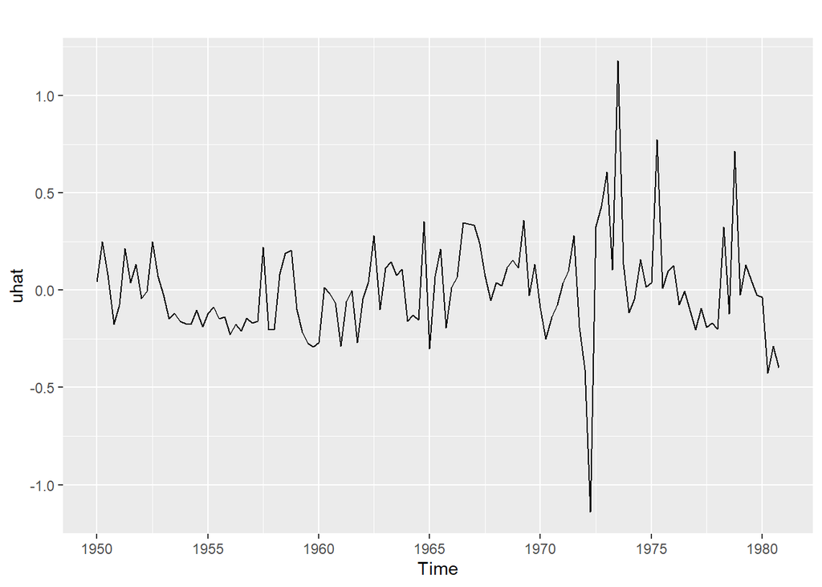

```r
# Residuals from the static regression
uhat <- residuals(intreg1)
autoplot(uhat)
```

```r
library(urca)
summary( ur.df(uhat , type = c("drift"), selectlags="AIC"))
```

```
##
## ###############################################
## # Augmented Dickey-Fuller Test Unit Root Test #
## ###############################################
##
## Test regression drift
##
##
## Call:
## lm(formula = z.diff ~ z.lag.1 + 1 + z.diff.lag)
##
## Residuals:
##      Min       1Q   Median       3Q      Max
## -1.01607 -0.13502 -0.03502  0.09798  1.07234
##
## Coefficients:
##             Estimate Std. Error t value Pr(>|t|)
## (Intercept) -0.00385    0.02257  -0.171    0.865
## z.lag.1     -0.63207    0.11208  -5.639 1.17e-07 ***
## z.diff.lag  -0.14605    0.09148  -1.597    0.113
## ---
## Signif. codes:  0 '***' 0.001 '**' 0.01 '*' 0.05 '.' 0.1 ' ' 1
##
## Residual standard error: 0.2492 on 119 degrees of freedom
## Multiple R-squared:  0.3814, Adjusted R-squared:  0.371
## F-statistic: 36.69 on 2 and 119 DF,  p-value: 3.867e-13
##
##
## Value of test-statistic is: -5.6392 15.9425
##
## Critical values for test statistics:
##       1pct  5pct 10pct
## tau2 -3.46 -2.88 -2.57
## phi1  6.52  4.63  3.81
```

$$\begin{aligned}\widehat{\Delta
\hat{u}}_t =& -0.004 -0.632 \hat{u}_{t-1} -0.146 \Delta
\hat{u}_{t-1} \\&~~~~(0.023)~~~~(0.112) ~~~~~~~~~~(0.091)
\end{aligned}$$

$$EG =
\frac{-0.632}{0.112}=-5.64$$

ADF kritik değerleri kullanılmamalıdır. EG kritik değerleri farklıdır. Tablo 18.4’de verilen (bkz. sunum notları) %1 kritik değeri -3.90’dır. EG test değeri bu değerden daha küçük olduğu için $H_0$ reddedilir. Bu iki değişken eşbütünleşiktir.

## 3.2 Örnek: Antalya ve İstanbul’da domates fiyatları

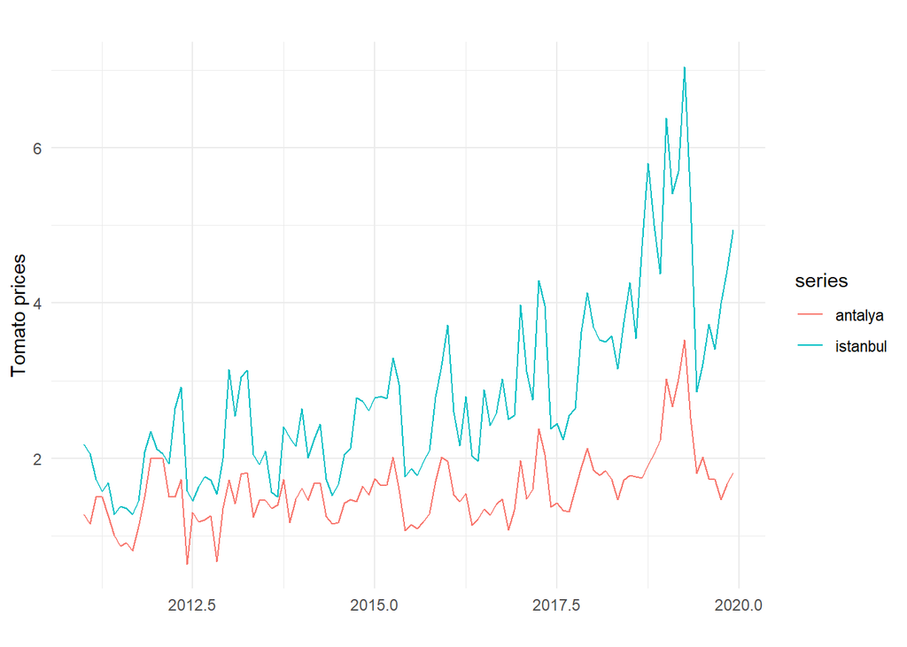

```r
load("../R/Data/tomatoprices.RData")
antalya <- ts(tomatoprices$antalya, start = 2011, frequency = 12)
istanbul <- ts(tomatoprices$istanbul, start = 2011, frequency = 12)
# plot of the series
library(forecast)
library(ggplot2)
autoplot(cbind(antalya, istanbul)) +
  theme_minimal() + xlab("") + ylab("Tomato prices")
```

Her iki fiyat serisinin I(1) olduğunu varsayalım (birim kök testleri ile karar verilebilir). Logaritmik fiyat serileri ile statik regresyon:

```r
res1 <- dynlm(log(istanbul) ~ trend(istanbul) + log(antalya))
summary(res1)
```

```
##
## Time series regression with "ts" data:
## Start = 2011(1), End = 2019(12)
##
## Call:
## dynlm(formula = log(istanbul) ~ trend(istanbul) + log(antalya))
##
## Residuals:
##      Min       1Q   Median       3Q      Max
## -0.35182 -0.10085 -0.00436  0.08620  0.39871
##
## Coefficients:
##                 Estimate Std. Error t value Pr(>|t|)
## (Intercept)     0.303658   0.031171   9.742 2.33e-16 ***
## trend(istanbul) 0.070355   0.006603  10.656  < 2e-16 ***
## log(antalya)    0.787020   0.062464  12.600  < 2e-16 ***
## ---
## Signif. codes:  0 '***' 0.001 '**' 0.01 '*' 0.05 '.' 0.1 ' ' 1
##
## Residual standard error: 0.1513 on 105 degrees of freedom
## Multiple R-squared:  0.8457, Adjusted R-squared:  0.8427
## F-statistic: 287.6 on 2 and 105 DF,  p-value: < 2.2e-16
```

Denklem formunda:
$$\widehat{\log(istanbul)}_t = 0.304 + 0.787
\log(antalya)_t + 0.070~ t$$

Bu sonuçlara göre Istanbul’daki fiyatların Antalya üretici fiyatlarına göre esnekliği yaklaşık 0.79’dur. Antalya’da fiyatlar %10 artarsa İstanbul’da fiyatlar yaklaşık %7.87 artar. Bu yorum sadece eşbütünleşme altında geçerlidir. Eğer fiyatlar eşbütünleşik değilse yukarıdaki regresyon kurmaca regresyondur ve sonuçlar geçersizdir.

Kalıntıların grafiği ve EG testi:

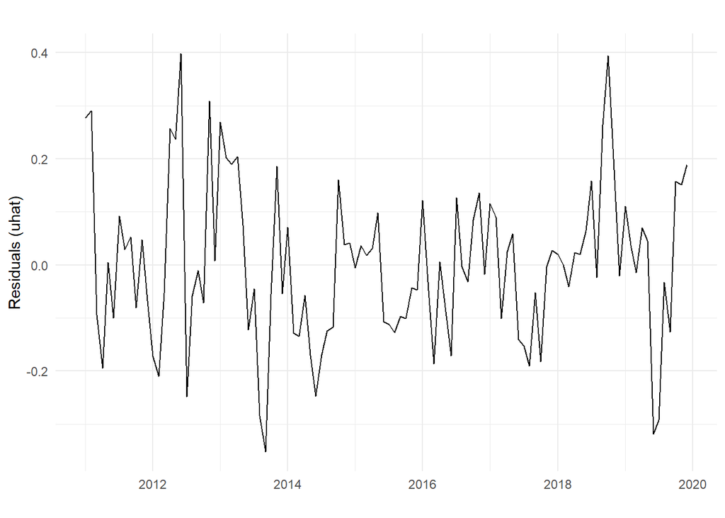

```r
uhat <- residuals(res1)
autoplot(uhat) + xlab("") + ylab("Residuals (uhat)")+theme_minimal()
```

```r
summary( ur.df(uhat , type = c("drift"), selectlags="AIC"))
```

```
##
## ###############################################
## # Augmented Dickey-Fuller Test Unit Root Test #
## ###############################################
##
## Test regression drift
##
##
## Call:
## lm(formula = z.diff ~ z.lag.1 + 1 + z.diff.lag)
##
## Residuals:
##      Min       1Q   Median       3Q      Max
## -0.39538 -0.08916  0.00043  0.08206  0.33896
##
## Coefficients:
##              Estimate Std. Error t value Pr(>|t|)
## (Intercept) -0.003684   0.013250  -0.278    0.782
## z.lag.1     -0.617421   0.107302  -5.754 9.02e-08 ***
## z.diff.lag  -0.010648   0.096932  -0.110    0.913
## ---
## Signif. codes:  0 '***' 0.001 '**' 0.01 '*' 0.05 '.' 0.1 ' ' 1
##
## Residual standard error: 0.1363 on 103 degrees of freedom
## Multiple R-squared:  0.3175, Adjusted R-squared:  0.3042
## F-statistic: 23.96 on 2 and 103 DF,  p-value: 2.861e-09
##
##
## Value of test-statistic is: -5.7541 16.5597
##
## Critical values for test statistics:
##       1pct  5pct 10pct
## tau2 -3.46 -2.88 -2.57
## phi1  6.52  4.63  3.81
```

EG eşbütünleşme test istatistiği -5.75 olarak hesaplandı. Bu EG kritik değerinden (trend dahil) daha küçüktür; öyleyse eşbütünleşmenin olmadığını söyleyen boş hipotez reddedilir. Antalya ve İstanbul domates fiyatları eşbütünleşiktir.

Hata düzeltme modeli:

```r
# an ECM
ecm1 <- dynlm(d(log(istanbul)) ~ L(uhat) +   L(d(log(antalya))))
summary(ecm1)
```

```
##
## Time series regression with "ts" data:
## Start = 2011(3), End = 2019(12)
##
## Call:
## dynlm(formula = d(log(istanbul)) ~ L(uhat) + L(d(log(antalya))))
##
## Residuals:
##      Min       1Q   Median       3Q      Max
## -0.57425 -0.11432  0.00044  0.12626  0.46735
##
## Coefficients:
##                     Estimate Std. Error t value Pr(>|t|)
## (Intercept)         0.005764   0.019911   0.289 0.772796
## L(uhat)            -0.520342   0.137625  -3.781 0.000262 ***
## L(d(log(antalya)))  0.079184   0.087141   0.909 0.365636
## ---
## Signif. codes:  0 '***' 0.001 '**' 0.01 '*' 0.05 '.' 0.1 ' ' 1
##
## Residual standard error: 0.2049 on 103 degrees of freedom
## Multiple R-squared:  0.1407, Adjusted R-squared:  0.124
## F-statistic: 8.432 on 2 and 103 DF,  p-value: 0.0004062
```

$$\begin{aligned}\widehat{\Delta
\log(istanbul)}_t =& 0.006 -0.52 \hat{s}_{t-1} + 0.08 \Delta
\log(antalya)_{t-1} \\&(0.020)~~(.138)
~~~~~~(.087)\end{aligned}$$

Burada $\hat{s}_{t-1} = \log(istanbul)_{t-1} - 0.304 - 0.787 \log(antalya)_{t-1} - 0.070 (t-1)$ eşbütünleşme ilişkisinden sapmaları gösterir.

Hata düzeltme parametresi (ayarlanma hızı parametresi) yaklaşık $-0.52$ olarak hesaplanmıştır ve istatistik bakımından anlamlıdır (t testi anlamlı).

Eğer İstanbul tüketici fiyatları denge ilişkisinin %1 puan üzerindeyse izleyen ayda fiyatlar yaklaşık olarak 0.52 puan azalacaktır. Denge ilişkisinden sapmanın yaklaşık olarak yarısı bir ay içinde düzeltilecektir.